## Introduction

The health and viability of freshwater fish populations depends on access to tributary and off channel areas which provide refuge during high flows, opportunities for foraging as well as overwintering, spawning and summer rearing habitats (Swales and Levings 1989; Bramblett et al. 2002). Culverts can present barriers to fish migration due to increased water velocity, turbulence, a vertical drop at the culvert outlet and/or maintenance issues (Whyte et al. 1997). In addition, open migration corridors are essential for adapting to the impacts of climate change such as rising water temperatures and changing flow regimes (Seliger and Zeiringer 2018). There are hundreds of culverts presenting barriers to fish passage in the Parsnip River watershed with some of these structures obstructing fish movement to valuable fish habitat (Gollner, Cain, and Russell 2013 ; Hooft 2014).

### Background

As a result of high-level direction from the provincial government of British Columbia, a Fish Passage Strategic Approach protocol has been developed for British Columbia to ensure that the greatest opportunities for restoration of fish passage are pursued. A Fish Passage Technical Working Group has been formed to coordinate the protocol and data is continuously amalgamated within the Provincial Stream Crossing Inventory System (PSCIS) which has been built to house all culvert related data. Historically, British Columbia Timber Sales has administered most of the fish passage assessment, design and remediation contracts in the province with the majority of funding typically provided by the Land Based Investment Strategy (LBIS). The strategic approach protocol for fish passage restoration involves a four-phase process as described in (Fish Passage Technical Working Group 2014):

- Phase 1: Fish Passage Assessment – Fish stream crossings within watersheds with high fish values are assessed to determine barrier status of structures and document a general assessment of adjacent habitat quality and quantity.
- Phase 2: Habitat Confirmation – Assessments of crossings prioritized for follow up in Phase 1 studies are conducted to confirm quality and quantity of habitat upstream and down as well as to scope for other potential nearby barriers that could affect the practicality of remediation.
- Phase 3: Design – Site plans and designs are drawn for priority crossings where high value fish habitat has been confirmed.
- Phase 4: Remediation – Implementation of re-connection of isolated habitats through replacement, rehabilitation or removal of prioritized crossing structure barriers.

The scope of this project included planning and implementation for Phase 2 of the strategic approach protocol in the Parsnip River watershed. The Parsnip River watershed was chosen for habitat confirmation actions due to its high fisheries values, because it is a watershed impacted by dam operations and because there has been significant investment in Phase 1 assessments since 2001 with 574 assessments for fish passage already completed.

### Study Area

The Parsnip River watershed is located within the south-eastern portion of the 108,000 km<sup>2</sup> traditional territory of the Tse’khene from the [McLeod Lake Indian Band](https://www.mlib.ca/about/History). The Tse’khene *“People of the Rocks”* are a south westerly extension of the Athabascan speaking people of northern Canada. They were a nomadic hunting people who’s language belongs to the Beaver-Sarcee-Tse’khene branch of Athapaskan (“History - Who We Are,” n.d.).

The continental divide separates watersheds flowing north into the Arctic Ocean via the Mackenzie River and south and west into the Pacific Ocean via the Fraser River. The Parsnip River is a 6th order stream with a watershed that drains an area of 5597 km<sup>2</sup>. The mainstem of the river flows within the Rocky Mountain Trench in a north direction into Williston Reservoir starting from the continental divide adjacent to Arctic Lakes. Major tributaries include the Misinchinka, Colbourne, Reynolds, Anzac, Table, Hominka and Missinka sub-basins which drain the western slopes of the Hart Ranges of the Rocky Mountains. The Parsnip River has a mean annual discharge of 147.6 m<sup>3</sup>/s with flow patterns typical of high elevation watersheds on the west side of the northern Rocky Mountains which receive large amounts of precipitation as snow leading to peak levels of discharge during snowmelt, typically from May to July (Figures 1 - 2).

Construction of the 183 m high and 2134 m long W.A.C. Bennett Dam was completed in 1967 at Hudson’s Hope, BC, creating Williston Reservoir (Hirst 1991). Filling of the 375 km<sup>2</sup> reservoir was complete in 1972 and flooded a substantial portion of the Parsnip River and major tributary valleys forming what is now known as the Peace and Parsnip reaches. The replacement of riverine habitat with an inundated reservoir environment resulted in profound changes to the ecology, resource use and human settlement patterns in these systems (Hagen et al. 2015; Stamford, Hagen, and Williamson 2017; Pearce 2019). Prior to the filling of the reservoir, the Pack River, into which McLeod Lake flows, was a major tributary to the Parsnip River. It now enters the Williston Reservoir directly as the historic location of the confluence of the two rivers lies within the reservoir’s footprint.

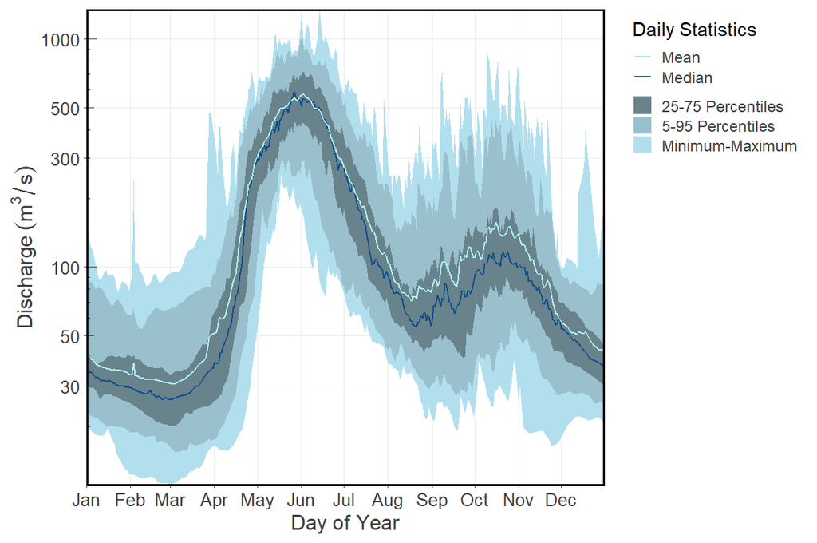

Figure 1: Parsnip River Above Misinchinka River (Station #07EE007 - Lat 55.08 Lon -122.91). Available daily discharge data from 1967 to 2015 plotted with tidyhydat (Albers 2017) and fasstr (Goetz and Schwarz 2020).

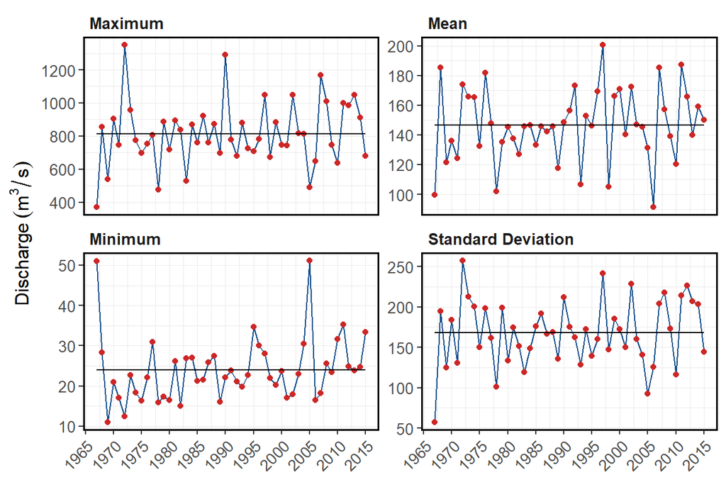

Figure 2: Summary discharge statistics (annual maximum, minimum, mean and standard deviation) for Parsnip River at hyrometric station #07EE007. Solid line is long term mean.

### Fisheries

Fish species recorded in the Parsnip River watershed are detailed in Table 1 (MoE 2019). In addition to flooding related to the formation of the Williston Reservoir, transmission lines, gas pipelines, rail, road networks, forestry, elevated water temperatures, interrupted connectivity, invasion from non-native species and insect infestations affecting forested areas pose threats to fisheries values in the Parsnip River watershed (Hagen et al. 2015; Stamford, Hagen, and Williamson 2017; Hagen and Weber 2019; Comittee on the Status of Endangered Wildlife in Canada 2012).

Table 1: Fish species recorded in the Parsnip River watershed.

| Scientific Name | Species Name | Species Code |
| --- | --- | --- |
| Catostomus catostomus | Longnose Sucker | LSU |
| Catostomus commersoni | White Sucker | WSU |
| Catostomus macrocheilus | Largescale Sucker | CSU |
| Coregonus clupeaformis | Lake Whitefish | LW |
| Cottus asper | Prickly Sculpin | CAS |
| Cottus cognatus | Slimy Sculpin | CCG |
| Couesius plumbeus | Lake Chub | LKC |
| Lota lota | Burbot | BB |
| Mylocheilus caurinus | Peamouth Chub | PCC |
| Oncorhynchus mykiss | Rainbow Trout | RB |
| Oncorhynchus nerka | Kokanee | KO |
| Prosopium coulteri | Pygmy Whitefish | PW |
| Prosopium williamsoni | Mountain Whitefish | MW |
| Ptychocheilus oregonensis | Northern Pikeminnow | NSC |
| Rhynichthys cataractae | Longnose Dace | LNC |
| Richardsonius balteatus | Redside Shiner | RSC |
| Salvelinus confluentus | Bull Trout | BT |
| Salvelinus fontinalis | Brook Trout | EB |
| Salvelinus namaycush | Lake Trout | LT |
| Thymallus arcticus | Arctic Grayling | GR |

#### Bull Trout

Bull Trout populations of the Williston Reservoir watershed are included within the Western Arctic ‘Designatable Unit’, which, in 2012, received a ranking of ‘Special Concern’ by the Committee on the Status of Endangered Wildlife in Canada (Comittee on the Status of Endangered Wildlife in Canada 2012). A study of Bull Trout critical habitats in the Parsnip River was conducted in 2014 with the Misinchinka and Anzac systems identified as the most important systems for large bodied bull trout spawners accounting for a combined total of 65% of spawners counted. The Table River was also highlighted as an important spawning destination accounting for an estimated 15% of the spawners. Other watersheds identified as containing runs of large bodied Bull Trout spawners included the Colbourne, Reynolds, Hominka and Missinka River with potentially less than 50 spawners utilizing each sub-basin (Hagen et al. 2015). Hagen and Weber (2019) have synthesized a large body of information regarding limiting factors, enhancement potential, critical habitats and conservation status for Bull Trout of the Williston Reservoir and the reader is encouraged to review this work for context. They have recommended experimental enhancements within a monitoring framework for Williston Reservoir Bull Trout (some spawning and rearing in Parsnip River mainstem and tributaries) which include stream fertilization, side channel development, riparian restoration and fish access improvement.

In 2018, sub-basins of the Anzac River watershed, Homininka River, Missinki River and Table River watersheds were designated as fisheries sensitive watersheds under the authority of the *Forest and Range Practices Act* due to significant downstream fisheries values and significant watershed sensitivity (Beaudry 2013a, 2014a, 2014b, 2013b). Special management is required in these watersheds to protect habitat for fish species including Bull Trout and Arctic Grayling including measures (among others) to limit equivalent clearcut area, reduce impacts to natural stream channel morphology, retain old growth attributes and maintain fish habitat/movement (Forest and Range Practices Act 2018).

#### Arctic Grayling

A detailed review of Arctic Grayling life history can be referenced in Stamford, Hagen, and Williamson (2017). Since impoundment of the Williston Reservoir, it appears that physical habitat and ecological changes have been the most significant factors limiting Arctic Grayling productivity. Although these changes are not well understood they have likely resulted in the inundation of key low gradient juvenile rearing and overwintering habitats, isolation of previously connected populations and increases in abundance of predators such as Bull Trout (Shrimpton, Roberts, and Clarke 2012; Hagen, Pillipow, and Gantner 2018).

Migration of mature adult Arctic Grayling occurs in the spring with arrival at known spawning locations coinciding with water temperatures of 4 $^\circ$C. Spawning in the Parsnip watershed appears to occur between late-May and late-June within sites located primarily within the lower reaches of the Anzac and Table rivers as well as within the Parsnip River mainstem. Side-channel and multiple-channel locations containing small gravels appear to be selected for spawning. Currently, the primary distribution of Williston Arctic Grayling appears to be among fourth order and larger streams (Williamson and Zimmerman 2005; Stamford, Hagen, and Williamson 2017). Although past study results indicate that 0+ grayling appeared to overwinter in lower reaches of larger tributaries (i.e. Table, Anzac rivers) as well as the Parsnip River and that few age-1+ grayling have been sampled in tributaries, habitat use in small tributaries and the extent they are connected with the mainstem habitats of all core areas is not well understood. Between 1995 and 2019, Arctic Grayling population monitoring has been conducted in the Table River in nine out of 25 years (8 years for the Anzac) using snorkel surveys. Results from 2018 are 2019 are intended to contributing to assessment of the conservation status of the species in the Parsnip Core area (Hagen, Pillipow, and Gantner 2018).

## Goals and Objectives

The overall goal of our project was to build capacity, awareness and momentum for fish passage restoration in the Parsnip Watershed. To realize this goal we created a short list of high priority culverts for fish passage restoration in the Parsnip River watershed through a data analysis exercise, scoping for First Nations input, fish passage assessments (BC Ministry of Environment 2011), habitat confirmation assessments (Fish Passage Technical Working Group 2011) and procurement of design specifications for a prioritized crossing.

## Methods

To identify priorities for crossing structure rehabilitation, background literature and the PSCIS database was reviewed for Parsnip River watershed streams and potential fish habitat associated with barrier and potential barrier culverts was analyzed within the context of outputs from the Fish Habitat Model (Norris and Mount 2016). The Fish Habitat Model was developed by the BC Ministry of Environment to provide estimates of the amount of fish habitat potentially located upstream of crossing locations.

Past fish passage assessment reports for the Parsnip River watershed were first reviewed to identify crossing structure barriers previously ranked as high or moderate priorities for rehabilitation. All crossings prioritized in past contractor reports underwent a detailed office review and ranking for follow up in the field. To identify previously un-prioritized crossing structure barriers located on potentially high value streams, road crossing structures that met the following criteria in the Fish Habitat Model and/or PSCIS database also underwent a detailed review to rank crossings for Phase 2 - Habitat Confirmations.

- Stream crossing barriers and potential barriers on streams with confirmed fish presence upstream of the structure.
- Stream crossing barriers and potential barriers on streams documented as ≥ 1.5m wide with linear lengths of modeled upstream habitat <22% gradient for ≥500 m.
- Stream crossing barriers and potential barriers located on streams classified as 3rd order or higher.
- Stream crossing barriers and potential barriers located on streams with >5 ha of modeled wetland and/or lake habitat upstream of the structure.
- Stream crossing barriers and potential barriers on streams with habitat value rated as “medium” or “high” in past fish passage assessment data.

A .kml file with crossing locations and rational for prioritizing for habitat confirmations was forwarded to provincial fish habitat biologists, McLeod Lake Indian Band staff, representatives from CN Rail, BC Timber Sales and Canfor Forest Products to provide an opportunity for review and scope for feedback.

In the field, PSCIS crossings ranked as high priorities for follow-up were assessed for fish passage following the procedures outlined in “Field Assessment for Determining Fish Passage Status of Closed Bottomed Structures” (MoE 2011) to confirm that the crossings were still barriers to fish passage. The following criteria, which act as hydraulic indices, were utilized to determine if a crossing was a barrier to fish passage: depth and degree of embedment, outlet drop, slope of culvert, stream width ratio (ratio of average downstream channel width to culvert width), and length of the culvert.

Habitat confirmations were completed in accordance with procedures outlined in the document “A Checklist for Fish Habitat Confirmation Prior to the Rehabilitation of a Stream Crossing” (FPTWG 2011). The main objective was to confirm that upstream habitat quantity and quality is sufficient to justify remediation of the crossing to provide fish passage, and to determine if any obstructions exist below the crossing. Structure replacement can be justified if there is a large quantity of high value habitat upstream of crossing barriers provided there are no fish migration barriers immediately downstream or upstream of the crossing.

## References

BC Ministry of Environment. 2011. *Field Assessment for Determining Fish Passage Status of Closed Bottom Structures*. Victoria, British Columbia: BC Ministry of Environment. https://www2.gov.bc.ca/assets/gov/environment/natural-resource-stewardship/land-based-investment/forests-for-tomorrow/field-assessment-for-determining-fish-passage-status-of-cbs.pdf.

Beaudry, Pierre G. 2013a. “Assessment and Assignment of Sensitivity Ratings to Sub-Basins of the Anzac Watershed in Parsnip Drainage – Ominieca Region. Contract Number: GS14823018.” Report. http://a100.gov.bc.ca/pub/acat/public/viewReport.do?reportId=51630.

———. 2013b. “Assessment and Assignment of Sensitivity Ratings to Sub-Basins of the Missinka Watershed in Parsnp Drainage – Ominieca Region. Contract Number: GS14FWH-006.” Report. P. Beaudry; Associates Ltd. http://a100.gov.bc.ca/pub/acat/public/viewReport.do?reportId=51631.

———. 2014a. “Assessment and Assignment of Sensitivity Ratings to Sub-Basins of the Hominka Watershed in Parsnip Drainage – Ominieca Region. Contract Number: GS15823011.” Report. http://a100.gov.bc.ca/pub/acat/public/viewReport.do?reportId=51633.

———. 2014b. “Assessment and Assignment of Sensitivity Ratings to Sub-Basins of the Table Watershed in Parsnip Drainage – Ominieca Region. Contract Number: GS15823011.” Report. http://a100.gov.bc.ca/pub/acat/public/viewReport.do?reportId=51634.

Bramblett, Robert, Mason Bryant, Brenda Wright, and Robert White. 2002. “Seasonal Use of Small Tributary and Main-Stem Habitats by Juvenile Steelhead, Coho Salmon, and Dolly Varden in a Southeastern Alaska Drainage Basin.” *Transactions of the American Fisheries Society* 131 (May): 498–506. https://doi.org/10.1577/1548-8659(2002)131<0498:SUOSTA>2.0.CO;2.

Comittee on the Status of Endangered Wildlife in Canada. 2012. “COSEWIC Assessment and Status Report on the Bull Trout Salvelinus Confluentus.” Report. https://www.sararegistry.gc.ca/virtual_sara/files/cosewic/sr_omble_tete_plat_bull_trout_1113_e.pdf.

Fish Passage Technical Working Group. 2011. *A Checklist for Fish Habitat Confirmation Prior to the Rehabilitation of a Stream Crossing.* https://www2.gov.bc.ca/gov/content/environment/natural-resource-stewardship/land-based-investment/investment-categories/fish-passage/habitat-confirmation-projects.

———. 2014. “Fish Passage Strategic Approach: Protocol for Prioritizing Sites for Fish Passage Remediation.” https://www2.gov.bc.ca/assets/gov/environment/plants-animals-and-ecosystems/fish-fish-habitat/fish-passage/strategic20approach20july202014.pdf.

Forest and Range Practices Act. 2018. “Order - Fisheries Sensitive Watershed Prince George Forest District.” http://www.env.gov.bc.ca/wld/frpa/fsw/approved.html.

Gollner, M C, Robijn Cain, and Krista Russell. 2013. “FISH PASSAGE CULVERT INVESTIGATIONS - Prince George Timber Sales Business Area - CONTRACT # PD13TGB001.” MarLim Ecological Consulting Ltd.

Hagen, John, Ray Pillipow, and Nikolaus Gantner. 2018. “Trend in Abundance of Arctic Grayling (Thymallus Arcticus) in Index Sites of the Parsnip River Watershed, 1995-2018.” 37.

Hagen, John, and Susanne Weber. 2019. “Limiting Factors, Enhancement Potential, Critical Habitats, and Conservation Status for Bull Trout of the Williston Reservoir Watershed: Information Synthesis and Recommended Monitoring Framework.” Report. http://fwcp.ca/app/uploads/2019/08/Bull-Trout-Info-Synthesis-Monitoring-Framework-_FINAL29Aug2019.pdf.

Hagen, John, Susanne Williamson, Mike Stamford, and Ray Pillipow. 2015. “Critical Habitats for Bull Trout and Arctic Grayling Within the Parsnip River and Pack River Watersheds.”

Hirst, S. M. 1991. “Impacts of the Operations of Existing Hydroelectric Developments on Fishery Resources in British Columbia.” https://waves-vagues.dfo-mpo.gc.ca/Library/124832main.pdf.

“History - Who We Are.” n.d. *McLeod Lake Indian Band*. https://www.mlib.ca/about/History.

Hooft, Jason. 2014. “Prince George Forest District: Parsnip Watershed 468 Locations Contract: PD14TGB003,” 25.

MoE. 2019. “Known Bc Fish Observations and Bc Fish Distributions.” Ministry of Environment and Climate Change Strategy - Knowledge Management. https://catalogue.data.gov.bc.ca/dataset/known-bc-fish-observations-and-bc-fish-distributions.

Norris, Simon, and Craig Mount. 2016. “Fish Passage Gis Analysis Version 2.2 – Methodology and Output Data Specifications.” https://data.skeenasalmon.info/dataset/bc-fish-passage-program.

Pearce, Dr Tristan. 2019. “First Nations Information Gathering on Kokanee, Bull Trout and Arctic Grayling: TSE’KHENE FIRST NATIONS - McLEOD LAKE INDIAN BAND,” 31.

Seliger, Carina, and Bernhard Zeiringer. 2018. “River Connectivity, Habitat Fragmentation and Related Restoration Measures.” In *Riverine Ecosystem Management*, edited by Stefan Schmutz and Jan Sendzimir, 171–86. Cham: Springer International Publishing. https://doi.org/10.1007/978-3-319-73250-3_9.

Shrimpton, J. M., S. L. Roberts, and A. D. Clarke. 2012. “Genetic Analysis of Arctic Grayling Population Structure in the Williston Watershedcfe3011493.Pdf.” http://a100.gov.bc.ca/appsdata/acat/documents/r38246/Report_311_GR_genetics_2012_1379090176074_c3e946726980918f9466d47b59978ad28ded2b969041dd7fe53b83cfe3011493.pdf.

Stamford, Mike, John Hagen, and Susanne Williamson. 2017. “FWCP Arctic Grayling Synthesis Report,” 148.

Swales, Stephen, and C. Levings. 1989. “Role of Off-Channel Ponds in the Life Cycle of Coho Salmon ( Oncorhynchus Kisutch ) and Other Juvenile Salmonids in the Coldwater River, British Columbia.” *Canadian Journal of Fisheries and Aquatic Sciences - CAN J FISHERIES AQUAT SCI* 46 (February): 232–42. https://doi.org/10.1139/f89-032.

Whyte, Ian, Scott Babakaiff, Mark A. Adam, and Paul A. Giroux. 1997. “Restoring Fish Access and Rehabilitation of Spawning Sites.” In *Fish Habitat Rehabilitation Procedures. Watershed Restoration Technical Circular No. 9*, edited by P. A. Slaney and D. Zaldokas, 5–1–5–13. Canadian Cataloguing in Publication Data. https://www.for.gov.bc.ca/hfd/library/FFIP/Slaney_PA1997_A.pdf.

Williamson, S. A, and J. T. Zimmerman. 2005. “Region 7a, Omineca Arctic Grayling (Thymallus Arcticus): Data Consolidation Review and Gap Analysis.” B.C. Ministry of Water, Land,; Air Protection.